# Modeling Heteroscedasticity with GLS

Xanthe Walker

2025-08-03

## Overview

In this workshop, we explore how to detect and model **heteroscedasticity**—a violation of the assumption that residuals have constant variance—in linear models. We’ll use the `nlme` package to fit **Generalized Least Squares (GLS)** models that account for changing variance across groups or with continuous predictors.

We use two case studies:

- **Mandible length among golden jackal populations** (heterogeneous group variances)
- **Sockeye salmon case study** (variance modeled as a function of a continuous predictor)

### Variance Structures in GLS

GLS models allow us to **weight observations differently** depending on variance structure. This helps improve inference and model fit when the assumption of constant variance is violated.

Here are common variance structures in ecological modeling:

| Function | Use Case | Syntax |
| --- | --- | --- |
| `varIdent()` | Different variance per group | `weights = varIdent(form = ~1 \| group)` |
| `varPower()` | Variance increases or decreases with a continuous covariate | `weights = varPower(form = ~ x)` |
| `varExp()` | Exponential change in variance with a covariate | `weights = varExp(form = ~ x)` |
| `varConstPower()` | Constant + power (good for small x-values) | `weights = varConstPower(form = ~ x)` |
| `varFixed()` | Known variances for each observation | `weights = varFixed(~ offset)` |
| `varComb()` | Combine group + continuous variance models | `weights = varComb(varIdent(...), varExp(...))` |

## Part 1: Differences in Mandible Length Among Populations

Here we test if there are differences in mandible lengths between populations of golden jackals.

To demonstrate heterogeneity of variance, we simulate jaw length data for five jackal populations. Each population has its own mean and residual variance, simulating realistic differences in size and measurement precision.

```r
set.seed(1)
ngroups <- 5
nsample <- 10
pop.means <- c(140, 145, 155, 140, 130)
sigma <- rep(c(16, 14, 12, 1.5, 11), each = nsample)
n <- ngroups * nsample
eps <- rnorm(n, 0, sigma)
x <- gl(ngroups, nsample, n, labels = LETTERS[1:5])
means <- rep(pop.means, each = nsample)
y <- as.numeric(means + eps)
jackal <- data.frame(jaw = y, pop = x)
```

### Visualize Group Variance

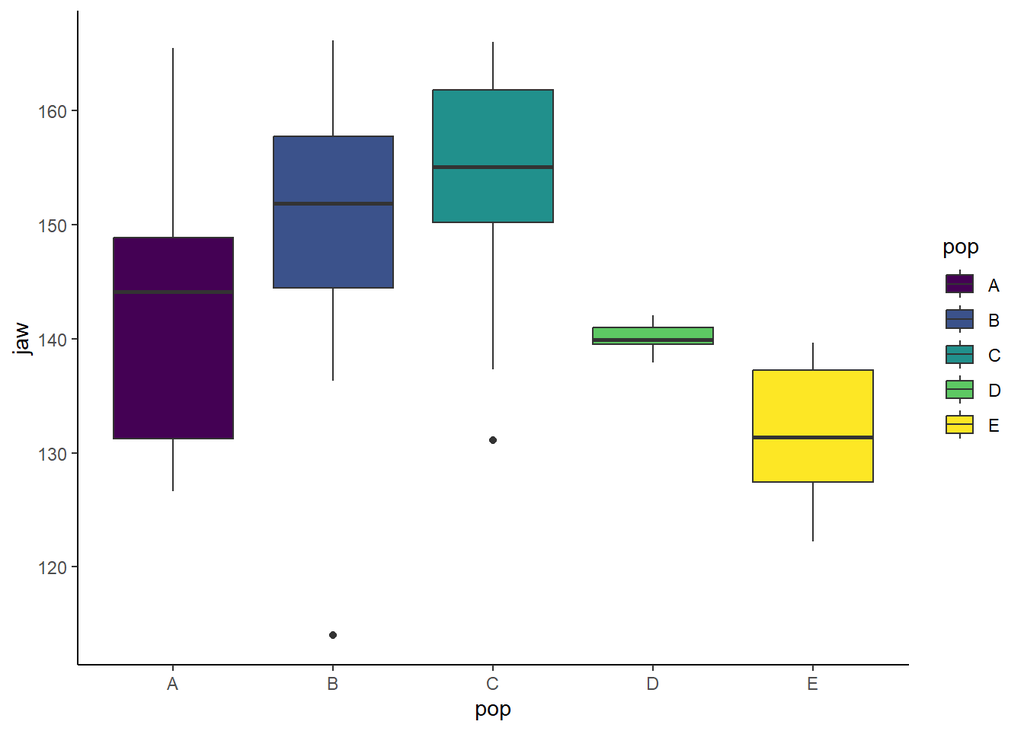

```r
ggplot(jackal, aes(x = pop, y = jaw, fill = pop)) + geom_boxplot() + theme_classic()+scale_fill_viridis_d()
```

There are visible differences in variation among groups. For regression models with categorical predictors, heterogeneity often shows up as differing spread in boxplots.

### Fit a linear model - a Homogeneous Model

```r
lm.jackal <- lm(jaw ~ pop, data = jackal)
summary(lm.jackal)
```

```
##
## Call:
## lm(formula = jaw ~ pop, data = jackal)
##
## Residuals:
##     Min      1Q  Median      3Q     Max
## -34.490  -4.012   0.877   6.512  23.409
##
## Coefficients:
##             Estimate Std. Error t value Pr(>|t|)
## (Intercept)  142.115      3.335  42.614   <2e-16 ***
## popB           6.369      4.716   1.350    0.184
## popC          11.281      4.716   2.392    0.021 *
## popD          -1.934      4.716  -0.410    0.684
## popE         -10.640      4.716  -2.256    0.029 *
## ---
## Signif. codes:  0 '***' 0.001 '**' 0.01 '*' 0.05 '.' 0.1 ' ' 1
##
## Residual standard error: 10.55 on 45 degrees of freedom
## Multiple R-squared:  0.3584, Adjusted R-squared:  0.3014
## F-statistic: 6.285 on 4 and 45 DF,  p-value: 0.0004173
```

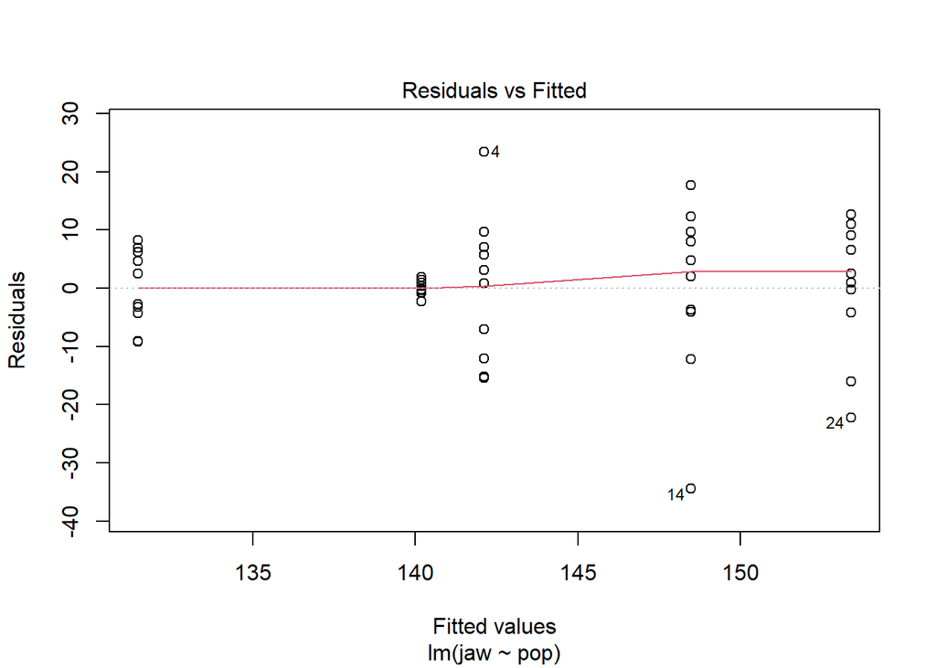

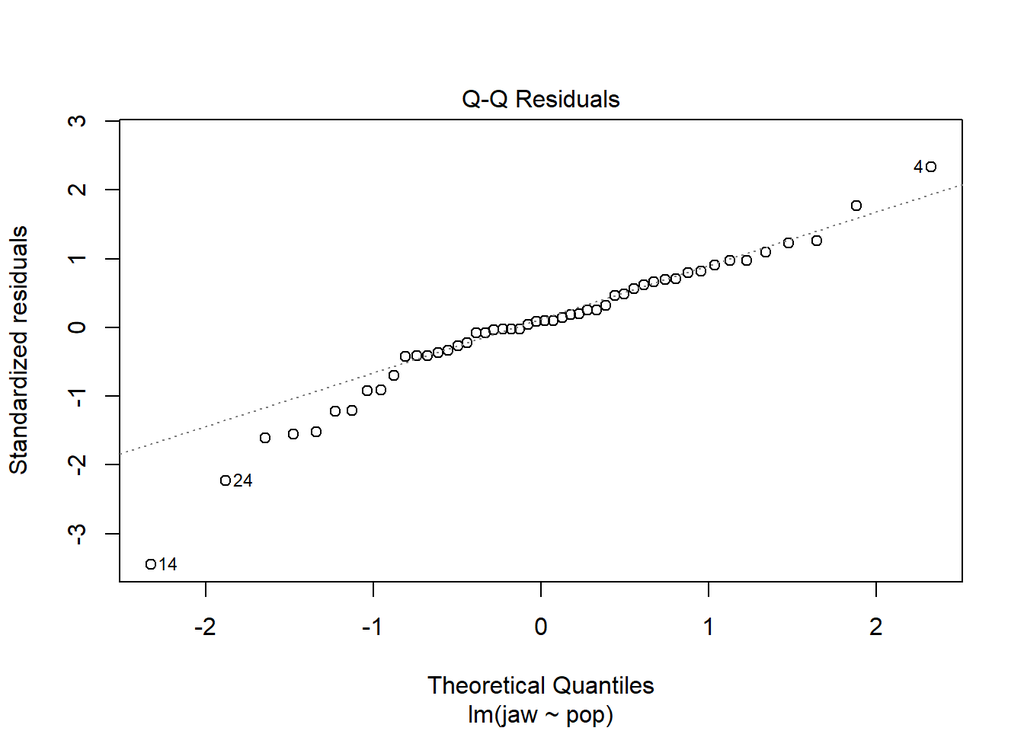

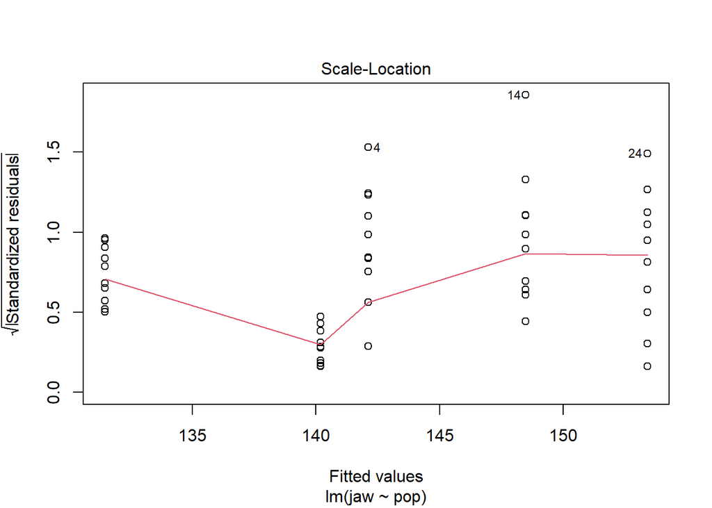

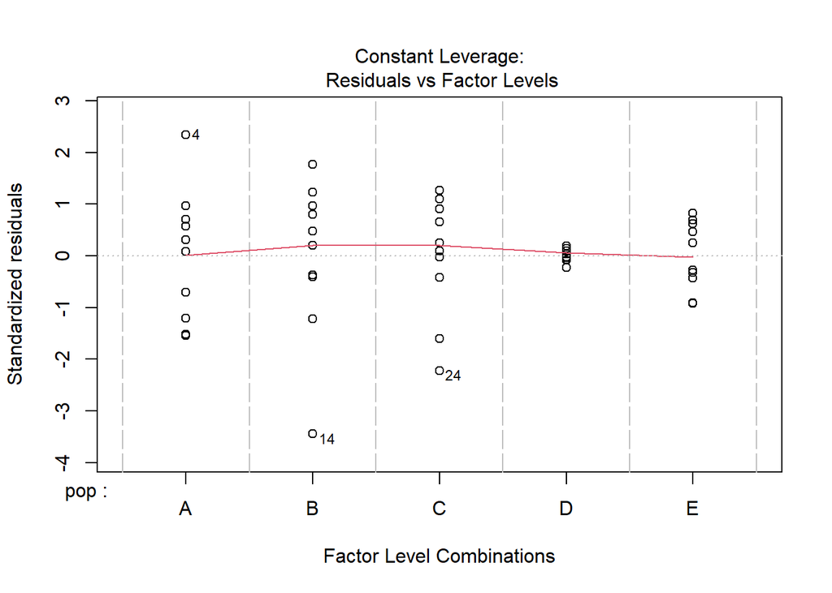

```r
plot(lm.jackal)
```

This model assumes homogeneity of variance, which may not be appropriate here.

### Fit a GLS model

The GLS model allows group-specific variances using the `varIdent()` function.

```r
gls.jackal <- gls(jaw ~ pop, weights = varIdent(form = ~1 | pop), data = jackal)
summary(gls.jackal)
```

```
## Generalized least squares fit by REML
##   Model: jaw ~ pop
##   Data: jackal
##        AIC      BIC    logLik
##   334.6022 352.6688 -157.3011
##
## Variance function:
##  Structure: Different standard deviations per stratum
##  Formula: ~1 | pop
##  Parameter estimates:
##          A          B          C          D          E
## 1.00000000 1.19887818 0.91816537 0.09711061 0.52472103
##
## Coefficients:
##                 Value Std.Error  t-value p-value
## (Intercept) 142.11524  3.949480 35.98328  0.0000
## popB          6.36859  6.165882  1.03287  0.3072
## popC         11.28068  5.361742  2.10392  0.0410
## popD         -1.93415  3.968059 -0.48743  0.6283
## popE        -10.63974  4.460172 -2.38550  0.0213
##
##  Correlation:
##      (Intr) popB   popC   popD
## popB -0.641
## popC -0.737  0.472
## popD -0.995  0.638  0.733
## popE -0.885  0.567  0.652  0.881
##
## Standardized residuals:
##        Min         Q1        Med         Q3        Max
## -2.3034220 -0.6178649  0.1064903  0.7596770  1.8743363
##
## Residual standard error: 12.48935
## Degrees of freedom: 50 total; 45 residual
```

We can compare the GLS model to the linear model (fit using `gls()` with no variance weights):

```r
gls.homog <- gls(jaw ~ pop, data = jackal)
anova(gls.homog, gls.jackal)
```

```
##            Model df      AIC      BIC    logLik   Test  L.Ratio p-value
## gls.homog      1  6 363.2352 374.0752 -175.6176
## gls.jackal     2 10 334.6022 352.6688 -157.3011 1 vs 2 36.63308  <.0001
```

> **Conclusion**: If the likelihood ratio test is significant and AIC is lower, the GLS model better accounts for heteroscedasticity.

### Residual Diagnostics

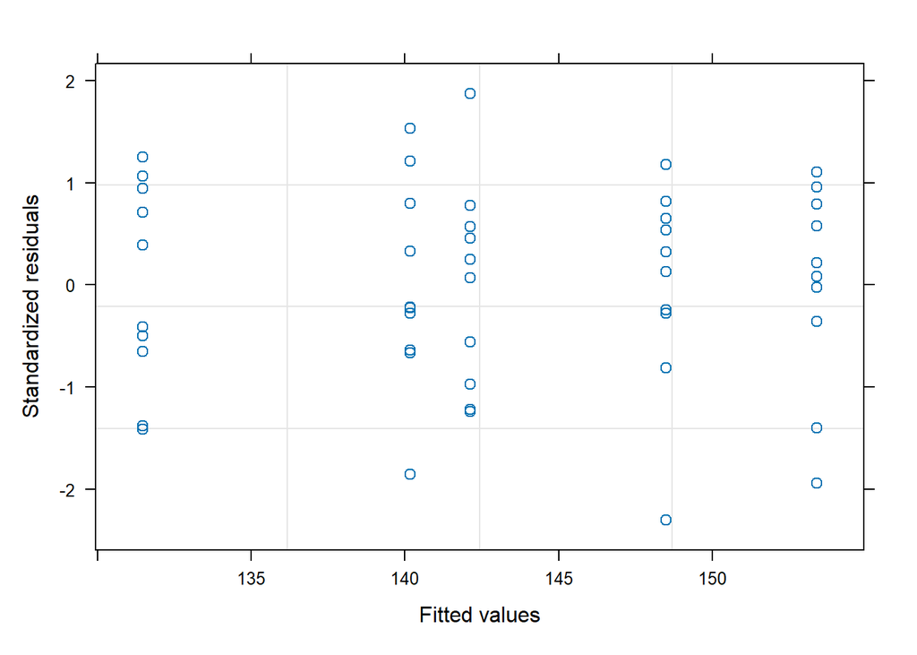

```r
plot(gls.jackal)
```

The residuals look more homoscedastic with the group-specific variance model.

> Using GLS gives us more flexibility and may improve coefficient precision when heteroscedasticity is present.

## Part 2: Sockeye Salmon Case Study

This dataset reflects sockeye salmon (*Oncorhynchus nerka*) returning to the Fraser River system. We are interested in modeling how well counts at Mission (MisEsc) predict harvest plus escapement (SpnEsc).

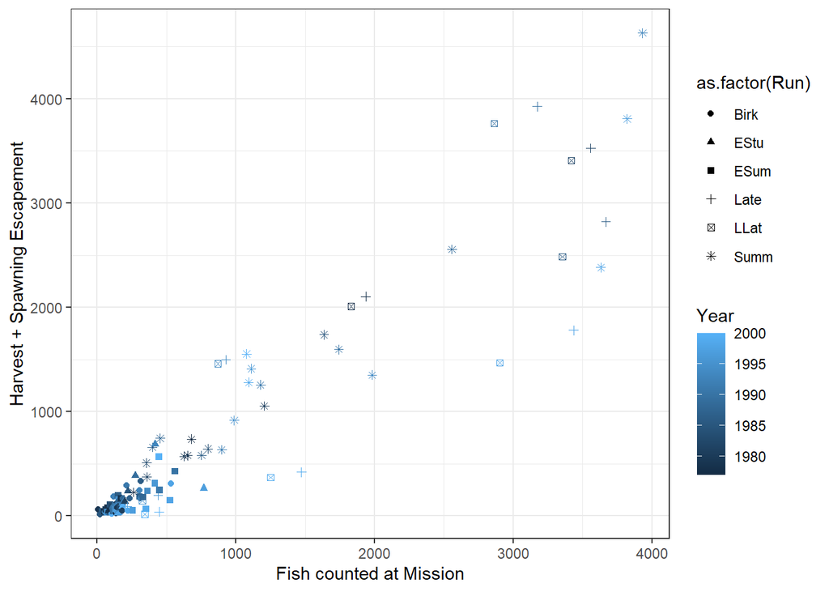

```r
salmon <- read.csv("../../Data files/Sockeyedata.csv")
ggplot(data = salmon, aes(x = MisEsc, y = SpnEsc, color = Year, shape = as.factor(Run))) +
  geom_point() +theme_bw()+
  labs(x = "Fish counted at Mission", y = "Harvest + Spawning Escapement")
```

### Fit a linear model

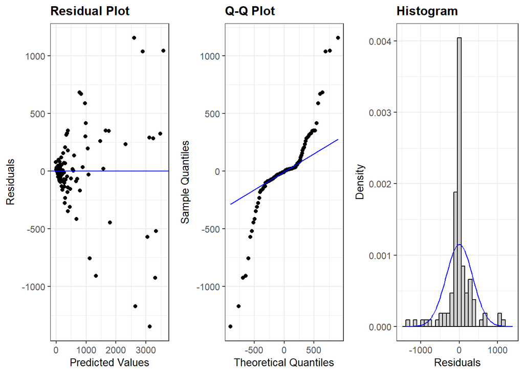

```r
lmsockeye <- lm(SpnEsc ~ MisEsc, data = salmon)
ggResidpanel::resid_panel(lmsockeye, plots = c("resid", "qq", "hist"), nrow = 1)
```

This model obviously violates the assumption of heterogeneity. We see a “fan shape” indicating that the variance increases with the number of fish passing Mission. The Q-Q plot and histogram of residuals also suggests that there are several large residuals, more than you would expect if the residuals came from a Normal distribution with constant variance.

### Fit models with different variance structures

```r
lmsockeye <- gls(SpnEsc ~ MisEsc, data = salmon)
fixedvar <- gls(SpnEsc ~ MisEsc, weights = varFixed(~ MisEsc), data = salmon)
varpow <- gls(SpnEsc ~ MisEsc, weights = varPower(form = ~ MisEsc), data = salmon)
varexp <- gls(SpnEsc ~ MisEsc, weights = varExp(form = ~ MisEsc), data = salmon)
varconstp <- gls(SpnEsc ~ MisEsc, weights = varConstPower(form = ~ MisEsc), data = salmon)
```

### Compare models

```r
anova(lmsockeye, fixedvar, varpow, varexp, varconstp)
```

```
##           Model df      AIC      BIC    logLik   Test  L.Ratio p-value
## lmsockeye     1  3 1614.925 1622.999 -804.4624
## fixedvar      2  3 1459.525 1467.599 -726.7625
## varpow        3  4 1446.861 1457.627 -719.4307 2 vs 3 14.66348   1e-04
## varexp        4  4 1482.668 1493.434 -737.3341
## varconstp     5  5 1421.523 1434.980 -705.7614 4 vs 5 63.14534  <.0001
```

> **Interpretation**: These models allow us to determine whether modeling variance as a function of fish count improves the fit. This is especially important when variance increases with the mean.

The **constant + power** model often performs well when the predictor can be near zero, offering a hybrid that handles increasing variance and base-level noise.

### Check final model

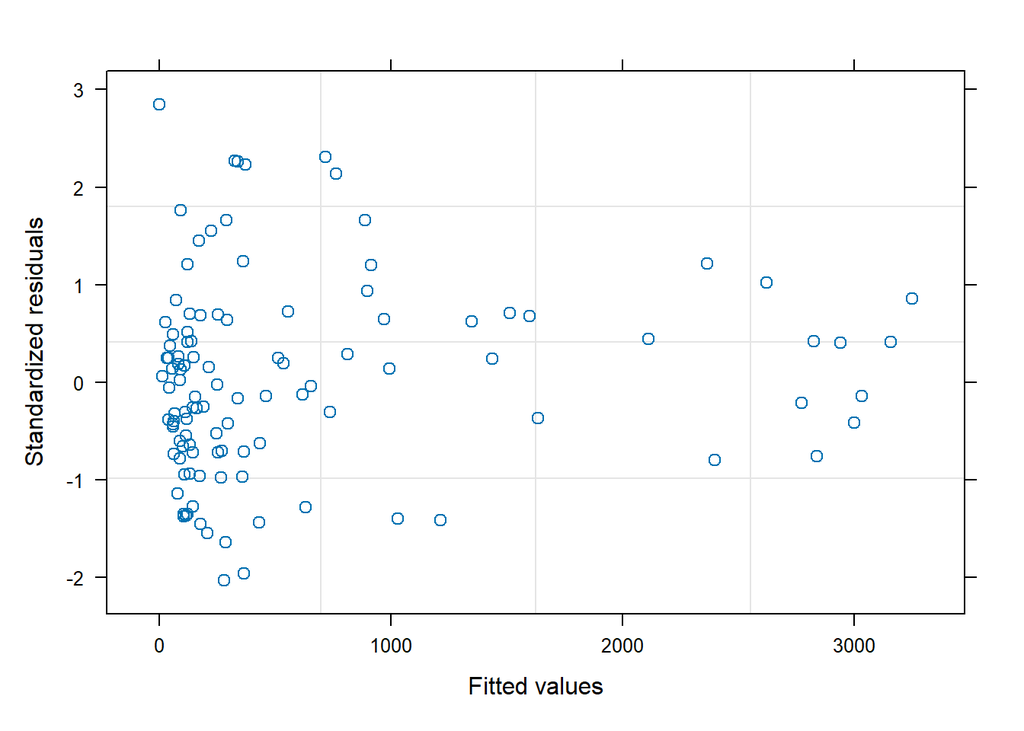

```r
plot(varconstp, plots = c("resid", "qq", "hist"), nrow = 3)
```

### Interpret model coefficients

```r
summary(varconstp)
```

```
## Generalized least squares fit by REML
##   Model: SpnEsc ~ MisEsc
##   Data: salmon
##        AIC     BIC    logLik
##   1421.523 1434.98 -705.7614
##
## Variance function:
##  Structure: Constant plus power of variance covariate
##  Formula: ~MisEsc
##  Parameter estimates:
##     const     power
## 119.49037   1.10369
##
## Coefficients:
##                 Value Std.Error   t-value p-value
## (Intercept) -6.122849  8.644421 -0.708301  0.4803
## MisEsc       0.828173  0.052627 15.736618  0.0000
##
##  Correlation:
##        (Intr)
## MisEsc -0.666
##
## Standardized residuals:
##         Min          Q1         Med          Q3         Max
## -2.03554341 -0.68214833 -0.03890184  0.61977181  2.85039770
##
## Residual standard error: 0.172081
## Degrees of freedom: 111 total; 109 residual
```

This model assumes residual variance increases with the covariate MisEsc. const (119.49) is the baseline variance. power (1.10) shows the rate of increase — here, residual variance increases super-linearly with MisEsc. This confirms heteroskedasticity: observations with higher MisEsc values have more variable residuals.

Intercept: When MisEsc = 0, the predicted SpnEsc is -6.12. This isn’t meaningful biologically (you’d never have 0 fish at Mission), but it anchors the model.

Slope for MisEsc (0.828): For each additional fish counted at Mission, we predict ~0.83 additional fish in harvest + spawning escapement.

p-value for MisEsc < 0.001: This predictor is highly significant.

p-value for Intercept = 0.48: Not significant, but this is rarely of interest in ecological regressions.

111 observations and 2 fixed effect parameters (intercept + slope).

### Plot the model results

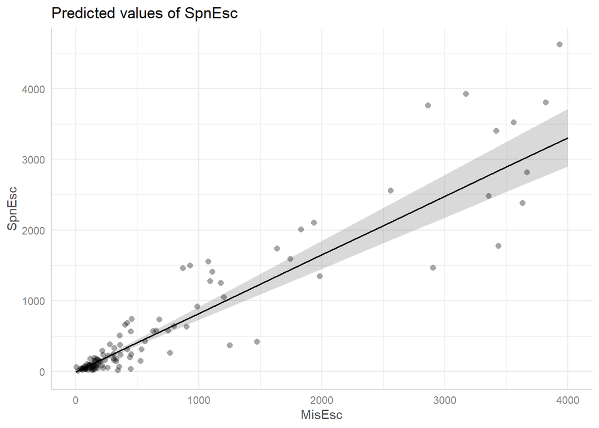

```r
plot(ggpredict(varconstp), show_data=TRUE)
```

## Exercise 1: Trunk Flare

Goal: Explore how well diameter at breast height (DBH) predicts trunk flare diameter in trees, and determine whether the relationship differs among species. Specifically, determine whether a GLS model that accounts for non-constant variance provides a better fit than a standard linear model.

1. **Read the data** from the `trunkfl.csv` file.
2. **View the first few lines** of data to confirm successful import and examine the structure.
3. **Subset the data** to include only Acer saccharinum (*Species = 4*).
4. **Make a scatter plot** of trunk flare vs. diameter at breast height (DBH) for Acer saccharinum. Include a fitted line.
5. **Fit a linear model** relating trunk flare to DBH using `lm()`. Use residual plots to evaluate model assumptions.
6. **Fit a GLS model** where variance increases with DBH using `varPower()`.
7. **Create diagnostic plots** of standardized residuals from the GLS model. Check homogeneity and normality assumptions using residual vs. fitted, QQ plots, and histograms.
8. **Use AIC to compare models**: Which model (LM vs GLS) gives the better fit?
9. **Compare parameter estimates** and their standard errors between LM and GLS. Do the estimates or inference change?
10. **Use the full dataset (all species)** to:
    - Fit a GLS model with the interaction between Species and DBH.
    - Identify the optimal variance structure.
    - Identify the optimal fixed effects structure (using AIC and nested model comparison).
    - Plot the final model and interpret the results.

## Exercise 2: Benthic Biodiversity

Goal: Evaluate how nutrient concentration in benthic mesocosms is influenced by macrofaunal biomass, enrichment (algae), and nutrient type. Test for and model heteroscedasticity using GLS, and identify the optimal fixed and variance structure for the data. Examine how model results change when a potential outlier is removed.

1. **Read the data** from the `Biodiversity.csv` file.
2. **Check the structure** of the dataset and confirm it imported correctly.
3. **Create a boxplot** showing the variation in concentration for each nutrient–enrichment combination. Is there visual evidence of heterogeneity?
4. **Fit a linear model** using biomass, enrichment, nutrient, all two-way interactions, and the three-way interaction.
5. **Examine residual plots**. Is the homogeneity of variance assumption met?
6. **Plot residuals vs predictors** (biomass, treatment, nutrient). Which variable(s) may be driving the heterogeneity?
7. **Fit GLS models** using different variance structures:
   - One accounting for treatment.
   - One accounting for nutrient.
   - One accounting for both treatment and nutrient interaction.
8. **Compare GLS models** using `anova()`. Which model best accounts for heterogeneity? Plot residuals to confirm.
9. **Use ML estimation** to test and refine the fixed effects structure:
   - Test the 3-way interaction.
   - Drop insignificant two-way interactions one at a time using likelihood ratio tests.
   - Finalize the fixed effects.
10. **Fit the final model using REML**. Check model assumptions. Identify any influential outliers.
11. **Summarize and visualize the final model.**
12. **Refit the model without the outlier.** Redo model selection and comparison. How do results change?